# P8130_final_project

Group 4: Yue Lai, Aiming Liu, Adeline Shin, Michael Yan

12/16/2019

# Importing and Tidying Data

```r
# tidying data and adding a column with the average salary
law_data = read_csv("./data/Lawsuit.csv") %>%
  janitor::clean_names() %>%
  mutate(dept = recode_factor(dept,
                              "1" = "Biochemistry/Molecular Biology",
                              "2" = "Physiology",
                              "3" = "Genetics",
                              "4" = "Pediatrics",
                              "5" = "Medicine",
                              "6" = "Surgery"),
         gender = recode_factor(gender,
                                "1" = "Male",
                                "0" = "Female"),
         clin = recode_factor(clin,
                              "1" = "Primarily clinical emphasis",
                              "0" = "Primarily research emphasis"),
         cert = recode_factor(cert,
                              "1" = "Board certified",
                              "0" = "Not certified"),
         rank = recode_factor(rank,
                              "1" = "Assistant",
                              "2" = "Associate",
                              "3" = "Full professor"),
         avg_salary = (sal94 + sal95) / 2)
```

# Data Exploration

## Initial Exploration

```r
# data exploration pt. 1
my_labels  =  list(dept = "Dept, n(%)",
                   clin = "Clin, n(%)",
                   cert = "Cert, n(%)",
                   prate = "Prate",
                   exper = "Exper",
                   rank = "Rank, n(%)",
                   sal94 = "Sal94",
                   sal95 = "Sal95",
                   avg_salary = "Average Salary")

my_controls = tableby.control(
               total = T,
               test = T,
               numeric.stats = c("meansd", "medianq1q3"),
               digits = 2,
               digits.pct = 2)

table1 = tableby(gender ~ dept + clin + cert + prate + exper + rank + sal94 + sal95 + avg_salary, data = law_data, control = my_controls)

summary(table1, labelTranslations = my_labels,
        title = "EDA", text = T) %>%
  knitr::kable()
```

|  | Male (N=155) | Female (N=106) | Total (N=261) | p value |
| --- | --- | --- | --- | --- |
| Dept, n(%) |  |  |  | < 0.001 |
| - Biochemistry/Molecular Biology | 30 (19.35%) | 20 (18.87%) | 50 (19.16%) |  |
| - Physiology | 20 (12.90%) | 20 (18.87%) | 40 (15.33%) |  |
| - Genetics | 10 (6.45%) | 11 (10.38%) | 21 (8.05%) |  |
| - Pediatrics | 10 (6.45%) | 20 (18.87%) | 30 (11.49%) |  |
| - Medicine | 50 (32.26%) | 30 (28.30%) | 80 (30.65%) |  |
| - Surgery | 35 (22.58%) | 5 (4.72%) | 40 (15.33%) |  |
| Clin, n(%) |  |  |  | 0.197 |
| - Primarily clinical emphasis | 100 (64.52%) | 60 (56.60%) | 160 (61.30%) |  |
| - Primarily research emphasis | 55 (35.48%) | 46 (43.40%) | 101 (38.70%) |  |
| Cert, n(%) |  |  |  | 0.074 |
| - Board certified | 118 (76.13%) | 70 (66.04%) | 188 (72.03%) |  |
| - Not certified | 37 (23.87%) | 36 (33.96%) | 73 (27.97%) |  |
| Prate |  |  |  | 0.004 |
| - Mean (SD) | 4.65 (1.94) | 5.35 (1.89) | 4.93 (1.94) |  |
| - Median (Q1, Q3) | 4.00 (3.10, 6.70) | 5.25 (3.73, 7.27) | 4.40 (3.20, 6.90) |  |
| Exper |  |  |  | < 0.001 |
| - Mean (SD) | 12.10 (6.70) | 7.49 (4.17) | 10.23 (6.23) |  |
| - Median (Q1, Q3) | 10.00 (7.00, 15.00) | 7.00 (5.00, 10.00) | 9.00 (6.00, 14.00) |  |
| Rank, n(%) |  |  |  | < 0.001 |
| - Assistant | 43 (27.74%) | 69 (65.09%) | 112 (42.91%) |  |
| - Associate | 43 (27.74%) | 21 (19.81%) | 64 (24.52%) |  |
| - Full professor | 69 (44.52%) | 16 (15.09%) | 85 (32.57%) |  |
| Sal94 |  |  |  | < 0.001 |
| - Mean (SD) | 177338.76 (85930.54) | 118871.27 (56168.01) | 153593.34 (80469.67) |  |
| - Median (Q1, Q3) | 155006.00 (109687.00, 231501.50) | 108457.00 (75774.50, 143096.00) | 133284.00 (90771.00, 200543.00) |  |
| Sal95 |  |  |  | < 0.001 |
| - Mean (SD) | 194914.09 (94902.73) | 130876.92 (62034.51) | 168906.66 (88778.43) |  |
| - Median (Q1, Q3) | 170967.00 (119952.50, 257163.00) | 119135.00 (82345.25, 154170.50) | 148117.00 (99972.00, 218955.00) |  |
| Average Salary |  |  |  | < 0.001 |
| - Mean (SD) | 186126.43 (90397.11) | 124874.09 (59089.62) | 161250.00 (84608.33) |  |
| - Median (Q1, Q3) | 162987.00 (114612.50, 244332.25) | 113706.00 (79059.88, 148401.12) | 141628.00 (95176.50, 210012.50) |  |

## Average Salary Exploration

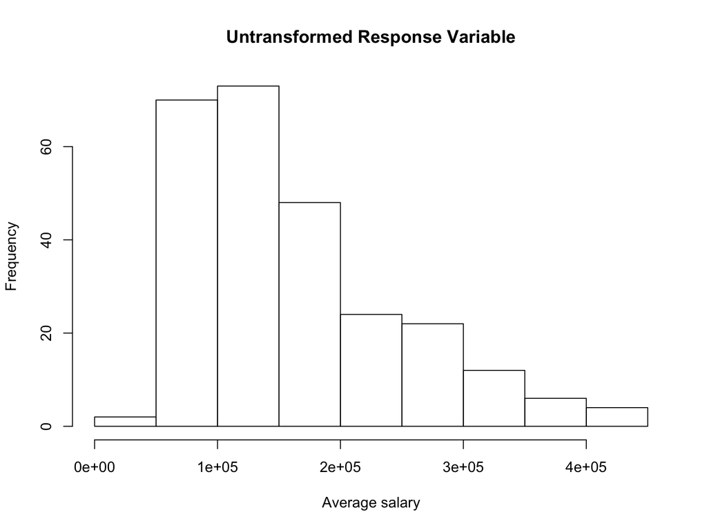

```r
# data exploration pt. 2
# investigate the shape of the distribution for variable ‘avg_salary’ and try different transformation
hist(law_data$avg_salary,
     main = "Untransformed Response Variable",
     xlab = "Average salary")
```

```r
yeojohnson(law_data$avg_salary)
```

```
## Standardized Yeo-Johnson Transformation with 261 nonmissing obs.:
##  Estimated statistics:
##  - lambda = -0.06327105
##  - mean (before standardization) = 8.339307
##  - sd (before standardization) = 0.2400873
```

From these results, we know to round up lambda and use the Log transformation of the response variable.

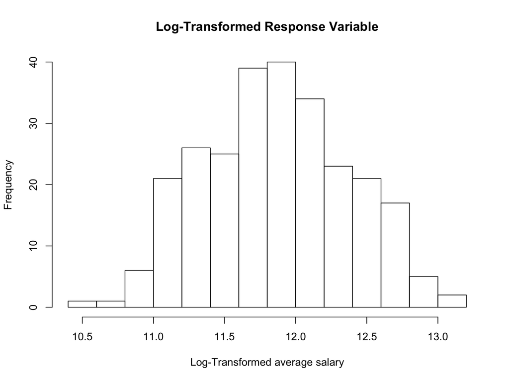

```r
hist(log(law_data$avg_salary),
main = "Log-Transformed Response Variable",
xlab = "Log-Transformed average salary")
```

After doing log-transformation, the histogram shows an approximate normal distribution of the response variable, in this case, the log-transformed average salary.

```r
law_data_1= read_csv("./data/Lawsuit.csv") %>%
  janitor::clean_names()
```

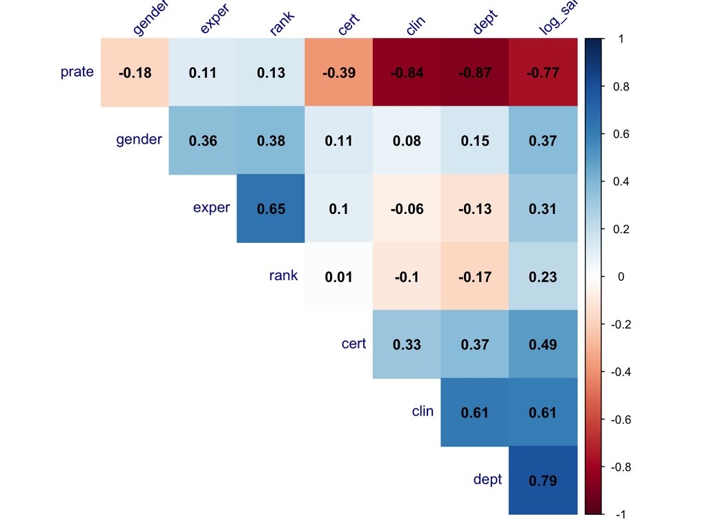

```r
law_data_cor = law_data_1 %>%
  mutate(log_sal = log((sal94 + sal95) / 2)) %>%
  dplyr::select(-id,-sal94,-sal95)

library(corrplot)
L_data = cor(as.matrix(law_data_cor))
corrplot(L_data, method = "color",
         type = "upper", order = "hclust",
         addCoef.col = "black", # Add coefficient of correlation
         tl.col = "darkblue", tl.srt = 45, #Text label color and rotation
         # hide correlation coefficient on the principal diagonal
         diag = FALSE
         )
```

# Finding Confounders

```r
# fit the model with only one variable:gender
law_data_change = law_data %>%
  select(gender,dept,clin,cert,exper,rank,avg_salary)

fit_sum = lm(log(avg_salary) ~ gender,data = law_data_change) %>%
  summary() %>%
  broom::tidy() %>%
  mutate(model = "log(avg_salary) ~ gender")

# fit all other predicators with gender
p_value_list = vector("list",length = 5)
for (i in 2:6) {
  fitml =
    as.formula(paste0("log(avg_salary) ~ gender +",names(law_data_change)[i],collapse = ""))
  p_value_list[[i - 1]] = summary(lm(fitml,data = law_data_change ))
}


p_value = vector("list",length = 5)
for (i in 1:5) {
  p_value[[i]] = broom::tidy(p_value_list[[i]]) %>%
    mutate(
      model = paste0("log(avg_salary) ~ gender +",names(law_data_change)[i + 1],collapse = "")
    )
}

# make a table to show the result
p_value = bind_rows(fit_sum,p_value)
confounder = p_value %>%
    dplyr::select(model,everything()) %>%
    filter(term == "genderFemale") %>%
    mutate(change_rate = round((-0.3853044 - estimate)/(-0.3853044),3)) %>%
    dplyr::select(model,term,estimate,change_rate)

knitr::kable(confounder)
```

| model | term | estimate | change_rate |
| --- | --- | --- | --- |
| log(avg_salary) ~ gender | genderFemale | -0.3853044 | 0.000 |
| log(avg_salary) ~ gender +dept | genderFemale | -0.2052080 | 0.467 |
| log(avg_salary) ~ gender +clin | genderFemale | -0.3371822 | 0.125 |
| log(avg_salary) ~ gender +cert | genderFemale | -0.3328485 | 0.136 |
| log(avg_salary) ~ gender +exper | genderFemale | -0.3075492 | 0.202 |
| log(avg_salary) ~ gender +rank | genderFemale | -0.3494810 | 0.093 |

In order to find confounders for the variable `gender`, the general criterion was used: if adding a variable changed the slope for `gender` by 10% or more, it should be considered a confounder.

Also, the change in slope of gender when adding `rank` was very close to 10%, so we decided to consider `rank` a confounder as well.

# Finding Interactions

```r
# fit all other predicators with gender
# Cody said we could not use this why to find interaction, we should refer some articles.
interaction_list = vector("list",length = 5)
for (i in 2:6) {
  fitml_inter =
    as.formula(paste0("log(avg_salary) ~ gender+dept+clin+cert+exper+rank+gender * ",names(law_data_change)[i],collapse = ""))
  interaction_list[[i - 1]] = summary(lm(fitml_inter,data = law_data_change))
}

#fit predicators with gender
interaction = vector("list",length = 5)
for (i in 2:6) {
  fitml_inter =
    as.formula(paste0("log(avg_salary) ~ gender+dept+clin+cert+exper+rank+gender * ",names(law_data_change)[i],collapse = ""))
  interaction[[i - 1]] = summary(lm(fitml_inter,data = law_data_change))
}

interaction_p_value = vector("list",length = 5)
for (i in 1:5) {
  interaction_p_value[[i]] = broom::tidy(interaction[[i]]) %>%
    mutate(
      model1 = paste0("log(avg_salary) ~ gender+dept+clin+cert+exper+rank+gender *",names(law_data_change)[i + 1],collapse = "")
    )
}

# make a table to show the results
interaction_p_value = bind_rows(interaction_p_value)
interaction_table = interaction_p_value %>%
    dplyr::select(model1,everything()) %>%
    filter(term != "(Intercept)") %>%
    dplyr::select(model1,everything())

knitr::kable(interaction_table)
```

| model1 | term | estimate | std.error | statistic | p.value |
| --- | --- | --- | --- | --- | --- |
| log(avg_salary) ~ gender+dept+clin+cert+exper+rank+gender *dept | genderFemale | 0.0158930 | 0.0403689 | 0.3936934 | 0.6941512 |
| log(avg_salary) ~ gender+dept+clin+cert+exper+rank+gender *dept | deptPhysiology | -0.1403233 | 0.0393547 | -3.5656050 | 0.0004367 |
| log(avg_salary) ~ gender+dept+clin+cert+exper+rank+gender *dept | deptGenetics | 0.2272647 | 0.0516667 | 4.3986712 | 0.0000163 |
| log(avg_salary) ~ gender+dept+clin+cert+exper+rank+gender *dept | deptPediatrics | 0.2282577 | 0.0524803 | 4.3493958 | 0.0000201 |
| log(avg_salary) ~ gender+dept+clin+cert+exper+rank+gender *dept | deptMedicine | 0.5549186 | 0.0359142 | 15.4512494 | 0.0000000 |
| log(avg_salary) ~ gender+dept+clin+cert+exper+rank+gender *dept | deptSurgery | 0.9555948 | 0.0402027 | 23.7694425 | 0.0000000 |
| log(avg_salary) ~ gender+dept+clin+cert+exper+rank+gender *dept | clinPrimarily research emphasis | -0.2060820 | 0.0222557 | -9.2597475 | 0.0000000 |
| log(avg_salary) ~ gender+dept+clin+cert+exper+rank+gender *dept | certNot certified | -0.1857898 | 0.0215909 | -8.6049948 | 0.0000000 |
| log(avg_salary) ~ gender+dept+clin+cert+exper+rank+gender *dept | exper | 0.0175403 | 0.0018305 | 9.5820572 | 0.0000000 |
| log(avg_salary) ~ gender+dept+clin+cert+exper+rank+gender *dept | rankAssociate | 0.1372005 | 0.0238238 | 5.7589738 | 0.0000000 |
| log(avg_salary) ~ gender+dept+clin+cert+exper+rank+gender *dept | rankFull professor | 0.2259445 | 0.0266848 | 8.4671719 | 0.0000000 |
| log(avg_salary) ~ gender+dept+clin+cert+exper+rank+gender *dept | genderFemale:deptPhysiology | -0.0778896 | 0.0579480 | -1.3441287 | 0.1801552 |
| log(avg_salary) ~ gender+dept+clin+cert+exper+rank+gender *dept | genderFemale:deptGenetics | -0.0876607 | 0.0718217 | -1.2205313 | 0.2234417 |
| log(avg_salary) ~ gender+dept+clin+cert+exper+rank+gender *dept | genderFemale:deptPediatrics | -0.0491623 | 0.0653651 | -0.7521187 | 0.4527046 |
| log(avg_salary) ~ gender+dept+clin+cert+exper+rank+gender *dept | genderFemale:deptMedicine | -0.0306368 | 0.0499404 | -0.6134666 | 0.5401393 |
| log(avg_salary) ~ gender+dept+clin+cert+exper+rank+gender *dept | genderFemale:deptSurgery | -0.0503143 | 0.0757976 | -0.6637980 | 0.5074463 |
| log(avg_salary) ~ gender+dept+clin+cert+exper+rank+gender *clin | genderFemale | -0.0114643 | 0.0243128 | -0.4715323 | 0.6376752 |
| log(avg_salary) ~ gender+dept+clin+cert+exper+rank+gender *clin | deptPhysiology | -0.1740418 | 0.0291732 | -5.9658190 | 0.0000000 |
| log(avg_salary) ~ gender+dept+clin+cert+exper+rank+gender *clin | deptGenetics | 0.1920132 | 0.0370018 | 5.1892992 | 0.0000004 |
| log(avg_salary) ~ gender+dept+clin+cert+exper+rank+gender *clin | deptPediatrics | 0.2023401 | 0.0357266 | 5.6635649 | 0.0000000 |
| log(avg_salary) ~ gender+dept+clin+cert+exper+rank+gender *clin | deptMedicine | 0.5406915 | 0.0295486 | 18.2983873 | 0.0000000 |
| log(avg_salary) ~ gender+dept+clin+cert+exper+rank+gender *clin | deptSurgery | 0.9387720 | 0.0358795 | 26.1645617 | 0.0000000 |
| log(avg_salary) ~ gender+dept+clin+cert+exper+rank+gender *clin | clinPrimarily research emphasis | -0.1905727 | 0.0282316 | -6.7503324 | 0.0000000 |
| log(avg_salary) ~ gender+dept+clin+cert+exper+rank+gender *clin | certNot certified | -0.1918997 | 0.0213533 | -8.9868703 | 0.0000000 |
| log(avg_salary) ~ gender+dept+clin+cert+exper+rank+gender *clin | exper | 0.0179597 | 0.0018271 | 9.8294531 | 0.0000000 |
| log(avg_salary) ~ gender+dept+clin+cert+exper+rank+gender *clin | rankAssociate | 0.1309647 | 0.0238484 | 5.4915484 | 0.0000001 |
| log(avg_salary) ~ gender+dept+clin+cert+exper+rank+gender *clin | rankFull professor | 0.2155217 | 0.0270955 | 7.9541351 | 0.0000000 |
| log(avg_salary) ~ gender+dept+clin+cert+exper+rank+gender *clin | genderFemale:clinPrimarily research emphasis | -0.0367497 | 0.0368877 | -0.9962570 | 0.3200963 |
| log(avg_salary) ~ gender+dept+clin+cert+exper+rank+gender *cert | genderFemale | -0.0215367 | 0.0229848 | -0.9369948 | 0.3496728 |
| log(avg_salary) ~ gender+dept+clin+cert+exper+rank+gender *cert | deptPhysiology | -0.1749321 | 0.0292643 | -5.9776541 | 0.0000000 |
| log(avg_salary) ~ gender+dept+clin+cert+exper+rank+gender *cert | deptGenetics | 0.1874489 | 0.0368015 | 5.0935119 | 0.0000007 |
| log(avg_salary) ~ gender+dept+clin+cert+exper+rank+gender *cert | deptPediatrics | 0.2021552 | 0.0359315 | 5.6261200 | 0.0000000 |
| log(avg_salary) ~ gender+dept+clin+cert+exper+rank+gender *cert | deptMedicine | 0.5389282 | 0.0295862 | 18.2155171 | 0.0000000 |
| log(avg_salary) ~ gender+dept+clin+cert+exper+rank+gender *cert | deptSurgery | 0.9343198 | 0.0356234 | 26.2277058 | 0.0000000 |
| log(avg_salary) ~ gender+dept+clin+cert+exper+rank+gender *cert | clinPrimarily research emphasis | -0.2091653 | 0.0220465 | -9.4874458 | 0.0000000 |
| log(avg_salary) ~ gender+dept+clin+cert+exper+rank+gender *cert | certNot certified | -0.1834992 | 0.0276241 | -6.6427308 | 0.0000000 |
| log(avg_salary) ~ gender+dept+clin+cert+exper+rank+gender *cert | exper | 0.0177031 | 0.0018164 | 9.7463802 | 0.0000000 |
| log(avg_salary) ~ gender+dept+clin+cert+exper+rank+gender *cert | rankAssociate | 0.1341146 | 0.0236493 | 5.6709660 | 0.0000000 |
| log(avg_salary) ~ gender+dept+clin+cert+exper+rank+gender *cert | rankFull professor | 0.2226805 | 0.0263282 | 8.4578745 | 0.0000000 |
| log(avg_salary) ~ gender+dept+clin+cert+exper+rank+gender *cert | genderFemale:certNot certified | -0.0138080 | 0.0389096 | -0.3548738 | 0.7229858 |
| log(avg_salary) ~ gender+dept+clin+cert+exper+rank+gender *exper | genderFemale | -0.1289315 | 0.0369123 | -3.4929169 | 0.0005656 |
| log(avg_salary) ~ gender+dept+clin+cert+exper+rank+gender *exper | deptPhysiology | -0.1650686 | 0.0287549 | -5.7405389 | 0.0000000 |
| log(avg_salary) ~ gender+dept+clin+cert+exper+rank+gender *exper | deptGenetics | 0.1897699 | 0.0358265 | 5.2969138 | 0.0000003 |
| log(avg_salary) ~ gender+dept+clin+cert+exper+rank+gender *exper | deptPediatrics | 0.2186033 | 0.0353421 | 6.1853479 | 0.0000000 |
| log(avg_salary) ~ gender+dept+clin+cert+exper+rank+gender *exper | deptMedicine | 0.5467712 | 0.0290446 | 18.8252583 | 0.0000000 |
| log(avg_salary) ~ gender+dept+clin+cert+exper+rank+gender *exper | deptSurgery | 0.9398303 | 0.0349067 | 26.9241031 | 0.0000000 |
| log(avg_salary) ~ gender+dept+clin+cert+exper+rank+gender *exper | clinPrimarily research emphasis | -0.2081748 | 0.0214696 | -9.6962597 | 0.0000000 |
| log(avg_salary) ~ gender+dept+clin+cert+exper+rank+gender *exper | certNot certified | -0.1821661 | 0.0209685 | -8.6875940 | 0.0000000 |
| log(avg_salary) ~ gender+dept+clin+cert+exper+rank+gender *exper | exper | 0.0160453 | 0.0018502 | 8.6722591 | 0.0000000 |
| log(avg_salary) ~ gender+dept+clin+cert+exper+rank+gender *exper | rankAssociate | 0.1182307 | 0.0236483 | 4.9995502 | 0.0000011 |
| log(avg_salary) ~ gender+dept+clin+cert+exper+rank+gender *exper | rankFull professor | 0.2080364 | 0.0261120 | 7.9670695 | 0.0000000 |
| log(avg_salary) ~ gender+dept+clin+cert+exper+rank+gender *exper | genderFemale:exper | 0.0117282 | 0.0035803 | 3.2757762 | 0.0012042 |
| log(avg_salary) ~ gender+dept+clin+cert+exper+rank+gender *rank | genderFemale | -0.0744792 | 0.0275681 | -2.7016480 | 0.0073777 |
| log(avg_salary) ~ gender+dept+clin+cert+exper+rank+gender *rank | deptPhysiology | -0.1755436 | 0.0288714 | -6.0801827 | 0.0000000 |
| log(avg_salary) ~ gender+dept+clin+cert+exper+rank+gender *rank | deptGenetics | 0.1845717 | 0.0362059 | 5.0978295 | 0.0000007 |
| log(avg_salary) ~ gender+dept+clin+cert+exper+rank+gender *rank | deptPediatrics | 0.2084679 | 0.0355285 | 5.8676302 | 0.0000000 |
| log(avg_salary) ~ gender+dept+clin+cert+exper+rank+gender *rank | deptMedicine | 0.5432042 | 0.0293638 | 18.4991281 | 0.0000000 |
| log(avg_salary) ~ gender+dept+clin+cert+exper+rank+gender *rank | deptSurgery | 0.9313875 | 0.0352673 | 26.4093558 | 0.0000000 |
| log(avg_salary) ~ gender+dept+clin+cert+exper+rank+gender *rank | clinPrimarily research emphasis | -0.1970312 | 0.0221749 | -8.8853197 | 0.0000000 |
| log(avg_salary) ~ gender+dept+clin+cert+exper+rank+gender *rank | certNot certified | -0.1912134 | 0.0213626 | -8.9508396 | 0.0000000 |
| log(avg_salary) ~ gender+dept+clin+cert+exper+rank+gender *rank | exper | 0.0181712 | 0.0018056 | 10.0637914 | 0.0000000 |
| log(avg_salary) ~ gender+dept+clin+cert+exper+rank+gender *rank | rankAssociate | 0.0901983 | 0.0312884 | 2.8828015 | 0.0042888 |
| log(avg_salary) ~ gender+dept+clin+cert+exper+rank+gender *rank | rankFull professor | 0.1770104 | 0.0317276 | 5.5790625 | 0.0000001 |
| log(avg_salary) ~ gender+dept+clin+cert+exper+rank+gender *rank | genderFemale:rankAssociate | 0.0829432 | 0.0447499 | 1.8534839 | 0.0650054 |
| log(avg_salary) ~ gender+dept+clin+cert+exper+rank+gender *rank | genderFemale:rankFull professor | 0.1052708 | 0.0466541 | 2.2564133 | 0.0249196 |

After referring to some papers, we found that `rank` and `exper`, may have been effect measure modifiers for the association between gender and salary. Therefore, we decided to use ANOVA to test the interactions.

## ANOVA Testing

```r
# ANOVA to determine the significance of interaction part
# interaction rank*gender
reg_in_rank = lm(log(avg_salary)~ exper + clin + cert + dept + gender * rank, data = law_data_change)
anova(reg_in_rank)
```

```
## Analysis of Variance Table
##
## Response: log(avg_salary)
##              Df  Sum Sq Mean Sq   F value    Pr(>F)
## exper         1  6.6666  6.6666  379.5144 < 2.2e-16 ***
## clin          1 26.7881 26.7881 1524.9813 < 2.2e-16 ***
## cert          1  4.8613  4.8613  276.7426 < 2.2e-16 ***
## dept          5 23.0117  4.6023  261.9992 < 2.2e-16 ***
## gender        1  0.2292  0.2292   13.0470 0.0003679 ***
## rank          2  1.3087  0.6543   37.2494 7.268e-15 ***
## gender:rank   2  0.1117  0.0559    3.1796 0.0433110 *
## Residuals   247  4.3389  0.0176
## ---
## Signif. codes:  0 '***' 0.001 '**' 0.01 '*' 0.05 '.' 0.1 ' ' 1
```

```r
# interaction exper*gender
reg_in_exper = lm(log(avg_salary)~ gender * exper + rank + cert + dept + clin, data = law_data_change)
anova(reg_in_exper)
```

```
## Analysis of Variance Table
##
## Response: log(avg_salary)
##               Df Sum Sq Mean Sq  F value    Pr(>F)
## gender         1  9.346  9.3456 543.2980 < 2.2e-16 ***
## exper          1  2.484  2.4843 144.4249 < 2.2e-16 ***
## rank           2  0.279  0.1397   8.1223  0.000383 ***
## cert           1 13.073 13.0729 759.9871 < 2.2e-16 ***
## dept           5 36.064  7.2127 419.3065 < 2.2e-16 ***
## clin           1  1.620  1.6198  94.1672 < 2.2e-16 ***
## gender:exper   1  0.185  0.1846  10.7307  0.001204 **
## Residuals    248  4.266  0.0172
## ---
## Signif. codes:  0 '***' 0.001 '**' 0.01 '*' 0.05 '.' 0.1 ' ' 1
```

# Initial Model after Considering Confounders and Interactions

```r
# initial model
reg_n_prate = lm(log(avg_salary)~ gender*rank + gender*exper+ clin + dept + cert , data = law_data_change)
summary(reg_n_prate)
```

```
##
## Call:
## lm(formula = log(avg_salary) ~ gender * rank + gender * exper +
##     clin + dept + cert, data = law_data_change)
##
## Residuals:
##      Min       1Q   Median       3Q      Max
## -0.31795 -0.07929 -0.01275  0.07078  0.85987
##
## Coefficients:
##                                  Estimate Std. Error t value Pr(>|t|)
## (Intercept)                     11.426406   0.037640 303.572  < 2e-16 ***
## genderFemale                    -0.133412   0.038125  -3.499 0.000554 ***
## rankAssociate                    0.101222   0.031438   3.220 0.001456 **
## rankFull professor               0.198141   0.032888   6.025 6.14e-09 ***
## exper                            0.016378   0.001965   8.334 5.54e-15 ***
## clinPrimarily research emphasis -0.205465   0.022327  -9.203  < 2e-16 ***
## deptPhysiology                  -0.166053   0.028962  -5.733 2.87e-08 ***
## deptGenetics                     0.188370   0.035963   5.238 3.49e-07 ***
## deptPediatrics                   0.219621   0.035606   6.168 2.82e-09 ***
## deptMedicine                     0.548131   0.029218  18.760  < 2e-16 ***
## deptSurgery                      0.939254   0.035170  26.706  < 2e-16 ***
## certNot certified               -0.181479   0.021644  -8.385 3.97e-15 ***
## genderFemale:rankAssociate       0.040275   0.048384   0.832 0.405994
## genderFemale:rankFull professor  0.018879   0.060486   0.312 0.755215
## genderFemale:exper               0.010471   0.004719   2.219 0.027410 *
## ---
## Signif. codes:  0 '***' 0.001 '**' 0.01 '*' 0.05 '.' 0.1 ' ' 1
##
## Residual standard error: 0.1315 on 246 degrees of freedom
## Multiple R-squared:  0.9368, Adjusted R-squared:  0.9332
## F-statistic: 260.5 on 14 and 246 DF,  p-value: < 2.2e-16
```

## Model Assumption Validation

Linear models rely on the following assumptions about the residuals: 1. Normally Distributed 2. They have the same variance at every predictor (Homoscedasticity) 3. They are independent of one another

These assumptions were tested using the following plots:

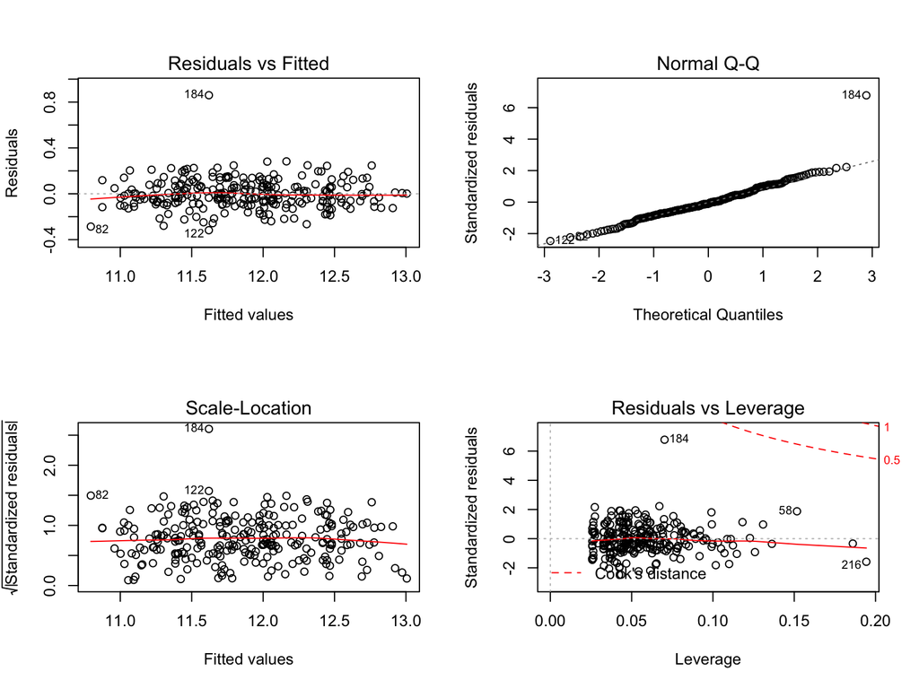

```r
# find outliers/influential points
law_model = lm(log(avg_salary)~ gender * rank + dept + clin + cert + exper * gender, data = law_data_change)

par(mfrow = c(2, 2))
plot(law_model)
```

As shown from these diagnostic graphs, point 184 was an outlier, and it was therefore removed from the overall dataset.

## Removing an Outlier

```r
# delete the outlier and build a new dataset
law_trans_minus = law_data[-c(184),]
```

After removing this outlier, the final model could be built with the updated dataset. Since there were effect measure modifiers found, the results were stratified by each of the variables found to have interaction earlier (`rank`, `exper`).

# Stratification of Model Results for Effect Measure Modifiers

## Stratification by Rank

```r
# seperate regression models for rank
rank_assi_minus =
  law_trans_minus %>%
  filter(rank == "Assistant")

rank_asso_minus =
  law_trans_minus %>%
  filter(rank == "Associate")

rank_prof_minus =
  law_trans_minus %>%
  filter(rank == "Full professor")

# Rank = Assistant: gender not significant
fit_assi_minus = lm(log(avg_salary)~ gender*exper +clin + dept+ cert, data = rank_assi_minus)
summary(fit_assi_minus)
```

```
##
## Call:
## lm(formula = log(avg_salary) ~ gender * exper + clin + dept +
##     cert, data = rank_assi_minus)
##
## Residuals:
##      Min       1Q   Median       3Q      Max
## -0.33464 -0.07689 -0.01220  0.09037  0.29707
##
## Coefficients:
##                                  Estimate Std. Error t value Pr(>|t|)
## (Intercept)                     11.362880   0.070957 160.137  < 2e-16 ***
## genderFemale                    -0.030542   0.060982  -0.501 0.617587
## exper                            0.028125   0.007119   3.951 0.000145 ***
## clinPrimarily research emphasis -0.246274   0.036948  -6.665 1.46e-09 ***
## deptPhysiology                  -0.217091   0.054788  -3.962 0.000139 ***
## deptGenetics                     0.143204   0.058359   2.454 0.015864 *
## deptPediatrics                   0.197665   0.057423   3.442 0.000844 ***
## deptMedicine                     0.528010   0.052870   9.987  < 2e-16 ***
## deptSurgery                      0.890892   0.061395  14.511  < 2e-16 ***
## certNot certified               -0.162946   0.035095  -4.643 1.05e-05 ***
## genderFemale:exper              -0.001452   0.009034  -0.161 0.872677
## ---
## Signif. codes:  0 '***' 0.001 '**' 0.01 '*' 0.05 '.' 0.1 ' ' 1
##
## Residual standard error: 0.1297 on 100 degrees of freedom
## Multiple R-squared:  0.9381, Adjusted R-squared:  0.9319
## F-statistic: 151.6 on 10 and 100 DF,  p-value: < 2.2e-16
```

```r
# Rank = Associate: gender significant
fit_asso_minus = lm(log(avg_salary)~ gender*exper + clin + dept+ cert, data = rank_asso_minus)
summary(fit_asso_minus)
```

```
##
## Call:
## lm(formula = log(avg_salary) ~ gender * exper + clin + dept +
##     cert, data = rank_asso_minus)
##
## Residuals:
##       Min        1Q    Median        3Q       Max
## -0.258976 -0.054641 -0.000157  0.054400  0.205004
##
## Coefficients:
##                                  Estimate Std. Error t value Pr(>|t|)
## (Intercept)                     11.484249   0.061486 186.777  < 2e-16 ***
## genderFemale                    -0.167617   0.083180  -2.015  0.04898 *
## exper                            0.020015   0.002598   7.703 3.34e-10 ***
## clinPrimarily research emphasis -0.210007   0.036514  -5.751 4.49e-07 ***
## deptPhysiology                  -0.187896   0.041806  -4.494 3.82e-05 ***
## deptGenetics                     0.175212   0.053624   3.267  0.00191 **
## deptPediatrics                   0.265609   0.058810   4.516 3.55e-05 ***
## deptMedicine                     0.534410   0.049526  10.791 5.50e-15 ***
## deptSurgery                      0.964730   0.056674  17.022  < 2e-16 ***
## certNot certified               -0.181370   0.031657  -5.729 4.87e-07 ***
## genderFemale:exper               0.019590   0.008410   2.329  0.02368 *
## ---
## Signif. codes:  0 '***' 0.001 '**' 0.01 '*' 0.05 '.' 0.1 ' ' 1
##
## Residual standard error: 0.09928 on 53 degrees of freedom
## Multiple R-squared:  0.9656, Adjusted R-squared:  0.9591
## F-statistic: 148.8 on 10 and 53 DF,  p-value: < 2.2e-16
```

```r
# Rank = Full professor: gender not significant
fit_prof_minus = lm(log(avg_salary)~  gender*exper + clin + dept+ cert, data = rank_prof_minus)
summary(fit_prof_minus)
```

```
##
## Call:
## lm(formula = log(avg_salary) ~ gender * exper + clin + dept +
##     cert, data = rank_prof_minus)
##
## Residuals:
##       Min        1Q    Median        3Q       Max
## -0.278734 -0.078911 -0.001255  0.076316  0.261704
##
## Coefficients:
##                                  Estimate Std. Error t value Pr(>|t|)
## (Intercept)                     11.653622   0.057791 201.650  < 2e-16 ***
## genderFemale                    -0.033947   0.127294  -0.267  0.79045
## exper                            0.014441   0.002370   6.093 4.56e-08 ***
## clinPrimarily research emphasis -0.185230   0.034932  -5.303 1.14e-06 ***
## deptPhysiology                  -0.126459   0.039065  -3.237  0.00181 **
## deptGenetics                     0.251458   0.055606   4.522 2.28e-05 ***
## deptPediatrics                   0.162844   0.066965   2.432  0.01744 *
## deptMedicine                     0.526385   0.039486  13.331  < 2e-16 ***
## deptSurgery                      0.948341   0.050545  18.762  < 2e-16 ***
## certNot certified               -0.253734   0.034846  -7.282 2.93e-10 ***
## genderFemale:exper               0.005502   0.009025   0.610  0.54401
## ---
## Signif. codes:  0 '***' 0.001 '**' 0.01 '*' 0.05 '.' 0.1 ' ' 1
##
## Residual standard error: 0.117 on 74 degrees of freedom
## Multiple R-squared:  0.9513, Adjusted R-squared:  0.9447
## F-statistic: 144.6 on 10 and 74 DF,  p-value: < 2.2e-16
```

As shown from these separate tables, there was a significant difference in salary among genders at the associate professor level, but not the assistant professor or full professor levels. The plot below shows these results graphically.

```r
# make a table to show the models stratified by rank
tab_model(fit_assi_minus,fit_asso_minus,fit_prof_minus,dv.labels = c("log(avg_salary):Assistant","log(avg_salary):Associate","log(avg_salary):Full professor"))
```

|  | log(avg_salary):Assistant |  |  | log(avg_salary):Associate |  |  | log(avg_salary):Full professor |  |  |
| --- | --- | --- | --- | --- | --- | --- | --- | --- | --- |
| Predictors | Estimates | CI | p | Estimates | CI | p | Estimates | CI | p |
| (Intercept) | 11.36 | 11.22 – 11.50 | **<0.001** | 11.48 | 11.36 – 11.61 | **<0.001** | 11.65 | 11.54 – 11.77 | **<0.001** |
| gender [Female] | -0.03 | -0.15 – 0.09 | 0.618 | -0.17 | -0.33 – -0.00 | **0.049** | -0.03 | -0.29 – 0.22 | 0.790 |
| exper | 0.03 | 0.01 – 0.04 | **<0.001** | 0.02 | 0.01 – 0.03 | **<0.001** | 0.01 | 0.01 – 0.02 | **<0.001** |
| clin [Primarily research emphasis] | -0.25 | -0.32 – -0.17 | **<0.001** | -0.21 | -0.28 – -0.14 | **<0.001** | -0.19 | -0.25 – -0.12 | **<0.001** |
| dept [Physiology] | -0.22 | -0.33 – -0.11 | **<0.001** | -0.19 | -0.27 – -0.10 | **<0.001** | -0.13 | -0.20 – -0.05 | **0.002** |
| dept [Genetics] | 0.14 | 0.03 – 0.26 | **0.016** | 0.18 | 0.07 – 0.28 | **0.002** | 0.25 | 0.14 – 0.36 | **<0.001** |
| dept [Pediatrics] | 0.20 | 0.08 – 0.31 | **0.001** | 0.27 | 0.15 – 0.38 | **<0.001** | 0.16 | 0.03 – 0.30 | **0.017** |
| dept [Medicine] | 0.53 | 0.42 – 0.63 | **<0.001** | 0.53 | 0.44 – 0.63 | **<0.001** | 0.53 | 0.45 – 0.61 | **<0.001** |
| dept [Surgery] | 0.89 | 0.77 – 1.01 | **<0.001** | 0.96 | 0.85 – 1.08 | **<0.001** | 0.95 | 0.85 – 1.05 | **<0.001** |
| cert [Not ified] | -0.16 | -0.23 – -0.09 | **<0.001** | -0.18 | -0.24 – -0.12 | **<0.001** | -0.25 | -0.32 – -0.18 | **<0.001** |
| gender [Female] * exper | -0.00 | -0.02 – 0.02 | 0.873 | 0.02 | 0.00 – 0.04 | **0.024** | 0.01 | -0.01 – 0.02 | 0.544 |
| Observations | 111 |  |  | 64 |  |  | 85 |  |  |
| R<sup>2</sup> / R<sup>2</sup> adjusted | 0.938 / 0.932 |  |  | 0.966 / 0.959 |  |  | 0.951 / 0.945 |  |  |

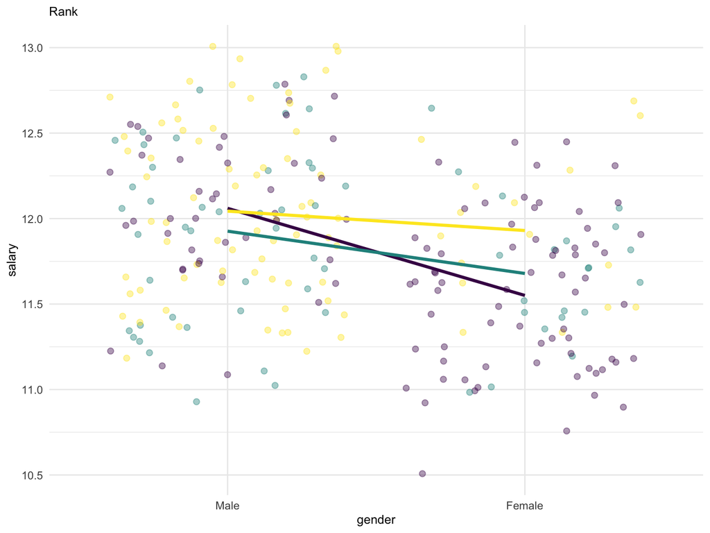

```r
# plot showing the interaction of rank
plot_rank =
  ggplot(aes(x = gender,y = log(avg_salary),colour = rank, fill =rank, group = rank),data = law_trans_minus)+
    geom_point(position ="jitter",size =2,  alpha =0.4)+
    geom_smooth(se = FALSE, fill ="lightgrey",method ="lm",alpha =0.6,size =1.2)+
    scale_colour_viridis_d("Rank")+
    scale_fill_viridis_d("Rank") +
    labs(title = "Rank",y="salary") +
    theme(plot.title = element_text(hjust = 0, size = 10), axis.text.x = element_text(size = 9), axis.title.x = element_text(size = 10), axis.text.y = element_text(size = 9), axis.title.y = element_text(size = 10), legend.position = "none")

plot_rank
```

## Stratification by Years of Experience

```r
# build a new dataset to stratify exper
law_data_exper = law_trans_minus %>%
  mutate(exper = case_when(exper <= 6 ~ "exper_6",
                           exper > 6 & exper <= 9 ~ "exper_6_9",
                           exper > 9 & exper <= 14 ~ "exper_9_14",
                               exper >= 14 ~ "exper_14"))
```

```r
# seperate regression model for exper (according to Q1, median, Q3)
exper_6_minus =
  law_data_exper %>%
  filter(exper == "exper_6")

exper_6_9_minus =
  law_data_exper %>%
  filter(exper == "exper_6_9")

exper_9_14_minus =
  law_data_exper %>%
  filter(exper == "exper_9_14")

exper_14_minus =
  law_data_exper %>%
  filter(exper == "exper_14")

# exper < 6
fit_6_minus = lm(log(avg_salary)~ gender*rank + dept + clin + cert, data = exper_6_minus)
summary(fit_6_minus)
```

```
##
## Call:
## lm(formula = log(avg_salary) ~ gender * rank + dept + clin +
##     cert, data = exper_6_minus)
##
## Residuals:
##      Min       1Q   Median       3Q      Max
## -0.33961 -0.07424 -0.01422  0.10397  0.29176
##
## Coefficients:
##                                 Estimate Std. Error t value Pr(>|t|)
## (Intercept)                     11.47097    0.08025 142.941  < 2e-16 ***
## genderFemale                    -0.05801    0.03717  -1.561  0.12305
## rankAssociate                    0.08005    0.08656   0.925  0.35816
## deptPhysiology                  -0.23692    0.07422  -3.192  0.00210 **
## deptGenetics                     0.20171    0.08318   2.425  0.01786 *
## deptPediatrics                   0.22871    0.08196   2.791  0.00675 **
## deptMedicine                     0.54135    0.07786   6.953 1.43e-09 ***
## deptSurgery                      0.92873    0.08896  10.440 5.46e-16 ***
## clinPrimarily research emphasis -0.18715    0.04446  -4.210 7.37e-05 ***
## certNot certified               -0.18042    0.03877  -4.654 1.47e-05 ***
## genderFemale:rankAssociate       0.01629    0.12531   0.130  0.89691
## ---
## Signif. codes:  0 '***' 0.001 '**' 0.01 '*' 0.05 '.' 0.1 ' ' 1
##
## Residual standard error: 0.1354 on 71 degrees of freedom
## Multiple R-squared:  0.928,  Adjusted R-squared:  0.9178
## F-statistic: 91.46 on 10 and 71 DF,  p-value: < 2.2e-16
```

```r
# 6 < exper <= 9
fit_6_9_minus = lm(log(avg_salary)~ gender*rank + dept + clin + cert, data = exper_6_9_minus)
summary(fit_6_9_minus)
```

```
##
## Call:
## lm(formula = log(avg_salary) ~ gender * rank + dept + clin +
##     cert, data = exper_6_9_minus)
##
## Residuals:
##       Min        1Q    Median        3Q       Max
## -0.194688 -0.071107 -0.000187  0.045226  0.260193
##
## Coefficients:
##                                  Estimate Std. Error t value Pr(>|t|)
## (Intercept)                     11.612158   0.068229 170.194  < 2e-16 ***
## genderFemale                    -0.057345   0.052334  -1.096 0.279290
## rankAssociate                    0.119853   0.051510   2.327 0.024753 *
## rankFull professor               0.225657   0.054846   4.114 0.000172 ***
## deptPhysiology                  -0.219286   0.047960  -4.572 4.05e-05 ***
## deptGenetics                     0.115339   0.065936   1.749 0.087383 .
## deptPediatrics                   0.115610   0.080743   1.432 0.159423
## deptMedicine                     0.494507   0.056945   8.684 5.21e-11 ***
## deptSurgery                      0.864821   0.070686  12.235 1.35e-15 ***
## clinPrimarily research emphasis -0.300386   0.052096  -5.766 8.00e-07 ***
## certNot certified               -0.139952   0.039144  -3.575 0.000880 ***
## genderFemale:rankAssociate       0.028964   0.072549   0.399 0.691693
## genderFemale:rankFull professor  0.002942   0.091311   0.032 0.974449
## ---
## Signif. codes:  0 '***' 0.001 '**' 0.01 '*' 0.05 '.' 0.1 ' ' 1
##
## Residual standard error: 0.1079 on 43 degrees of freedom
## Multiple R-squared:  0.9645, Adjusted R-squared:  0.9546
## F-statistic: 97.46 on 12 and 43 DF,  p-value: < 2.2e-16
```

```r
# 9 < exper <= 14
fit_9_14_minus = lm(log(avg_salary)~ gender*rank + dept + clin + cert, data = exper_9_14_minus)
summary(fit_9_14_minus)
```

```
##
## Call:
## lm(formula = log(avg_salary) ~ gender * rank + dept + clin +
##     cert, data = exper_9_14_minus)
##
## Residuals:
##       Min        1Q    Median        3Q       Max
## -0.308129 -0.077535  0.008848  0.085948  0.239358
##
## Coefficients:
##                                  Estimate Std. Error t value Pr(>|t|)
## (Intercept)                     11.742698   0.081377 144.299  < 2e-16 ***
## genderFemale                    -0.006887   0.087245  -0.079  0.93736
## rankAssociate                    0.065816   0.073711   0.893  0.37567
## rankFull professor               0.147870   0.071490   2.068  0.04315 *
## deptPhysiology                  -0.153878   0.052179  -2.949  0.00462 **
## deptGenetics                     0.146349   0.067178   2.179  0.03352 *
## deptPediatrics                   0.123815   0.063323   1.955  0.05546 .
## deptMedicine                     0.470845   0.056014   8.406 1.46e-11 ***
## deptSurgery                      0.941628   0.065999  14.267  < 2e-16 ***
## clinPrimarily research emphasis -0.248370   0.040351  -6.155 8.00e-08 ***
## certNot certified               -0.223660   0.044657  -5.008 5.62e-06 ***
## genderFemale:rankAssociate       0.022793   0.102806   0.222  0.82533
## genderFemale:rankFull professor  0.061847   0.106847   0.579  0.56498
## ---
## Signif. codes:  0 '***' 0.001 '**' 0.01 '*' 0.05 '.' 0.1 ' ' 1
##
## Residual standard error: 0.126 on 57 degrees of freedom
## Multiple R-squared:  0.9477, Adjusted R-squared:  0.9367
## F-statistic: 86.06 on 12 and 57 DF,  p-value: < 2.2e-16
```

```r
# exper > 14
fit_14_minus = lm(log(avg_salary)~ gender*rank + dept + clin + cert, data = exper_14_minus)
summary(fit_14_minus)
```

```
##
## Call:
## lm(formula = log(avg_salary) ~ gender * rank + dept + clin +
##     cert, data = exper_14_minus)
##
## Residuals:
##       Min        1Q    Median        3Q       Max
## -0.239122 -0.094397  0.007539  0.065736  0.227209
##
## Coefficients:
##                                 Estimate Std. Error t value Pr(>|t|)
## (Intercept)                     11.53750    0.11864  97.248  < 2e-16 ***
## genderFemale                     0.11458    0.17747   0.646  0.52228
## rankAssociate                    0.38434    0.11616   3.309  0.00202 **
## rankFull professor               0.35500    0.10715   3.313  0.00200 **
## deptPhysiology                  -0.04519    0.06859  -0.659  0.51389
## deptGenetics                     0.25535    0.08027   3.181  0.00287 **
## deptPediatrics                   0.15699    0.09071   1.731  0.09141 .
## deptMedicine                     0.60155    0.05792  10.385 8.68e-13 ***
## deptSurgery                      0.97829    0.07325  13.355 3.93e-16 ***
## clinPrimarily research emphasis -0.11763    0.05048  -2.330  0.02507 *
## certNot certified               -0.32354    0.05285  -6.122 3.50e-07 ***
## genderFemale:rankAssociate      -0.17423    0.22987  -0.758  0.45304
## genderFemale:rankFull professor -0.09442    0.18878  -0.500  0.61978
## ---
## Signif. codes:  0 '***' 0.001 '**' 0.01 '*' 0.05 '.' 0.1 ' ' 1
##
## Residual standard error: 0.132 on 39 degrees of freedom
## Multiple R-squared:  0.9372, Adjusted R-squared:  0.9179
## F-statistic:  48.5 on 12 and 39 DF,  p-value: < 2.2e-16
```

As shown in the summaries of the stratification for years of experience, gender is not a significant variable in any of the stratified models. These results are also shown in the plot below.

```r
# make a table to show the models stratified by exper
tab_model(fit_6_minus,fit_6_9_minus,fit_9_14_minus,fit_14_minus,dv.labels = c("log(avg_salary):exper_6","log(avg_salary):exper_6_9","log(avg_salary):exper_9_14","log(avg_salary):exper_14"))
```

|  | log(avg_salary):exper_6 |  |  | log(avg_salary):exper_6_9 |  |  | log(avg_salary):exper_9_14 |  |  | log(avg_salary):exper_14 |  |  |
| --- | --- | --- | --- | --- | --- | --- | --- | --- | --- | --- | --- | --- |
| Predictors | Estimates | CI | p | Estimates | CI | p | Estimates | CI | p | Estimates | CI | p |
| (Intercept) | 11.47 | 11.31 – 11.63 | **<0.001** | 11.61 | 11.47 – 11.75 | **<0.001** | 11.74 | 11.58 – 11.91 | **<0.001** | 11.54 | 11.30 – 11.78 | **<0.001** |
| gender [Female] | -0.06 | -0.13 – 0.02 | 0.123 | -0.06 | -0.16 – 0.05 | 0.279 | -0.01 | -0.18 – 0.17 | 0.937 | 0.11 | -0.24 – 0.47 | 0.522 |
| rank [Associate] | 0.08 | -0.09 – 0.25 | 0.358 | 0.12 | 0.02 – 0.22 | **0.025** | 0.07 | -0.08 – 0.21 | 0.376 | 0.38 | 0.15 – 0.62 | **0.002** |
| dept [Physiology] | -0.24 | -0.38 – -0.09 | **0.002** | -0.22 | -0.32 – -0.12 | **<0.001** | -0.15 | -0.26 – -0.05 | **0.005** | -0.05 | -0.18 – 0.09 | 0.514 |
| dept [Genetics] | 0.20 | 0.04 – 0.37 | **0.018** | 0.12 | -0.02 – 0.25 | 0.087 | 0.15 | 0.01 – 0.28 | **0.034** | 0.26 | 0.09 – 0.42 | **0.003** |
| dept [Pediatrics] | 0.23 | 0.07 – 0.39 | **0.007** | 0.12 | -0.05 – 0.28 | 0.159 | 0.12 | -0.00 – 0.25 | 0.055 | 0.16 | -0.03 – 0.34 | 0.091 |
| dept [Medicine] | 0.54 | 0.39 – 0.70 | **<0.001** | 0.49 | 0.38 – 0.61 | **<0.001** | 0.47 | 0.36 – 0.58 | **<0.001** | 0.60 | 0.48 – 0.72 | **<0.001** |
| dept [Surgery] | 0.93 | 0.75 – 1.11 | **<0.001** | 0.86 | 0.72 – 1.01 | **<0.001** | 0.94 | 0.81 – 1.07 | **<0.001** | 0.98 | 0.83 – 1.13 | **<0.001** |
| clin [Primarily research emphasis] | -0.19 | -0.28 – -0.10 | **<0.001** | -0.30 | -0.41 – -0.20 | **<0.001** | -0.25 | -0.33 – -0.17 | **<0.001** | -0.12 | -0.22 – -0.02 | **0.025** |
| cert [Not ified] | -0.18 | -0.26 – -0.10 | **<0.001** | -0.14 | -0.22 – -0.06 | **0.001** | -0.22 | -0.31 – -0.13 | **<0.001** | -0.32 | -0.43 – -0.22 | **<0.001** |
| gender [Female] * rank [Associate] | 0.02 | -0.23 – 0.27 | 0.897 | 0.03 | -0.12 – 0.18 | 0.692 | 0.02 | -0.18 – 0.23 | 0.825 | -0.17 | -0.64 – 0.29 | 0.453 |
| rank [Full professor] |  |  |  | 0.23 | 0.12 – 0.34 | **<0.001** | 0.15 | 0.00 – 0.29 | **0.043** | 0.35 | 0.14 – 0.57 | **0.002** |
| gender [Female] * rank [Full professor] |  |  |  | 0.00 | -0.18 – 0.19 | 0.974 | 0.06 | -0.15 – 0.28 | 0.565 | -0.09 | -0.48 – 0.29 | 0.620 |
| Observations | 82 |  |  | 56 |  |  | 70 |  |  | 52 |  |  |
| R<sup>2</sup> / R<sup>2</sup> adjusted | 0.928 / 0.918 |  |  | 0.965 / 0.955 |  |  | 0.948 / 0.937 |  |  | 0.937 / 0.918 |  |  |

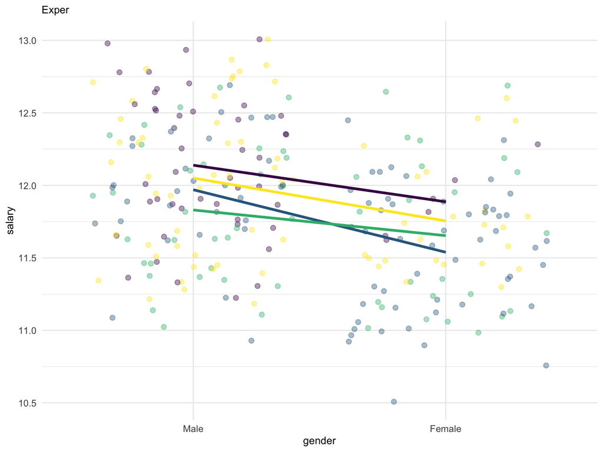

```r
# plot showing the interaction of exper
plot_exper =
  ggplot(aes(x = gender,y = log(avg_salary),colour = exper, fill = exper, group = exper),data = law_data_exper)+
    geom_point(position ="jitter",size =2,  alpha =0.4)+
    geom_smooth(se = FALSE, fill ="lightgrey",method ="lm",alpha =0.6,size =1.2)+
    scale_colour_viridis_d("Exper")+
    scale_fill_viridis_d("Exper") +
    labs(title = "Exper",y="salary") +
    theme(plot.title = element_text(hjust = 0, size = 10), axis.text.x = element_text(size = 9), axis.title.x = element_text(size = 10), axis.text.y = element_text(size = 9), axis.title.y = element_text(size = 10), legend.position = "none")

plot_exper
```

# Final Model

After determining which variables were confounders and effect measure modifiers, as well as removing outliers, the final recommended model is:

```r
#final model after deleting the outlier
final_law_model = lm(log(avg_salary)~ gender * rank + dept + clin + cert +  gender*exper, data = law_trans_minus)
summary(final_law_model)
```

```
##
## Call:
## lm(formula = log(avg_salary) ~ gender * rank + dept + clin +
##     cert + gender * exper, data = law_trans_minus)
##
## Residuals:
##      Min       1Q   Median       3Q      Max
## -0.32895 -0.07173 -0.01277  0.08089  0.28179
##
## Coefficients:
##                                  Estimate Std. Error t value Pr(>|t|)
## (Intercept)                     11.424964   0.034009 335.937  < 2e-16 ***
## genderFemale                    -0.100527   0.034725  -2.895  0.00413 **
## rankAssociate                    0.127014   0.028612   4.439 1.37e-05 ***
## rankFull professor               0.215776   0.029808   7.239 5.81e-12 ***
## deptPhysiology                  -0.172382   0.026182  -6.584 2.77e-10 ***
## deptGenetics                     0.183611   0.032499   5.650 4.45e-08 ***
## deptPediatrics                   0.200148   0.032276   6.201 2.36e-09 ***
## deptMedicine                     0.520522   0.026654  19.529  < 2e-16 ***
## deptSurgery                      0.922849   0.031852  28.973  < 2e-16 ***
## clinPrimarily research emphasis -0.225913   0.020356 -11.098  < 2e-16 ***
## certNot certified               -0.198053   0.019681 -10.063  < 2e-16 ***
## exper                            0.016930   0.001777   9.526  < 2e-16 ***
## genderFemale:rankAssociate       0.011198   0.043888   0.255  0.79882
## genderFemale:rankFull professor -0.002157   0.054723  -0.039  0.96858
## genderFemale:exper               0.009676   0.004265   2.269  0.02416 *
## ---
## Signif. codes:  0 '***' 0.001 '**' 0.01 '*' 0.05 '.' 0.1 ' ' 1
##
## Residual standard error: 0.1188 on 245 degrees of freedom
## Multiple R-squared:  0.9483, Adjusted R-squared:  0.9454
## F-statistic: 321.2 on 14 and 245 DF,  p-value: < 2.2e-16
```

```r
# make a table to show the final model
tab_model(final_law_model)
```

|  | log(avg salary) |  |  |
| --- | --- | --- | --- |
| Predictors | Estimates | CI | p |
| (Intercept) | 11.42 | 11.36 – 11.49 | **<0.001** |
| gender [Female] | -0.10 | -0.17 – -0.03 | **0.004** |
| rank [Associate] | 0.13 | 0.07 – 0.18 | **<0.001** |
| rank [Full professor] | 0.22 | 0.16 – 0.27 | **<0.001** |
| dept [Physiology] | -0.17 | -0.22 – -0.12 | **<0.001** |
| dept [Genetics] | 0.18 | 0.12 – 0.25 | **<0.001** |
| dept [Pediatrics] | 0.20 | 0.14 – 0.26 | **<0.001** |
| dept [Medicine] | 0.52 | 0.47 – 0.57 | **<0.001** |
| dept [Surgery] | 0.92 | 0.86 – 0.99 | **<0.001** |
| clin [Primarily research emphasis] | -0.23 | -0.27 – -0.19 | **<0.001** |
| cert [Not ified] | -0.20 | -0.24 – -0.16 | **<0.001** |
| exper | 0.02 | 0.01 – 0.02 | **<0.001** |
| gender [Female] * rank [Associate] | 0.01 | -0.08 – 0.10 | 0.799 |
| gender [Female] * rank [Full professor] | -0.00 | -0.11 – 0.11 | 0.969 |
| gender [Female] * exper | 0.01 | 0.00 – 0.02 | **0.024** |
| Observations | 260 |  |  |
| R<sup>2</sup> / R<sup>2</sup> adjusted | 0.948 / 0.945 |  |  |

## Final Model Assumptions

Below are the plots to test the assumptions for the final model:

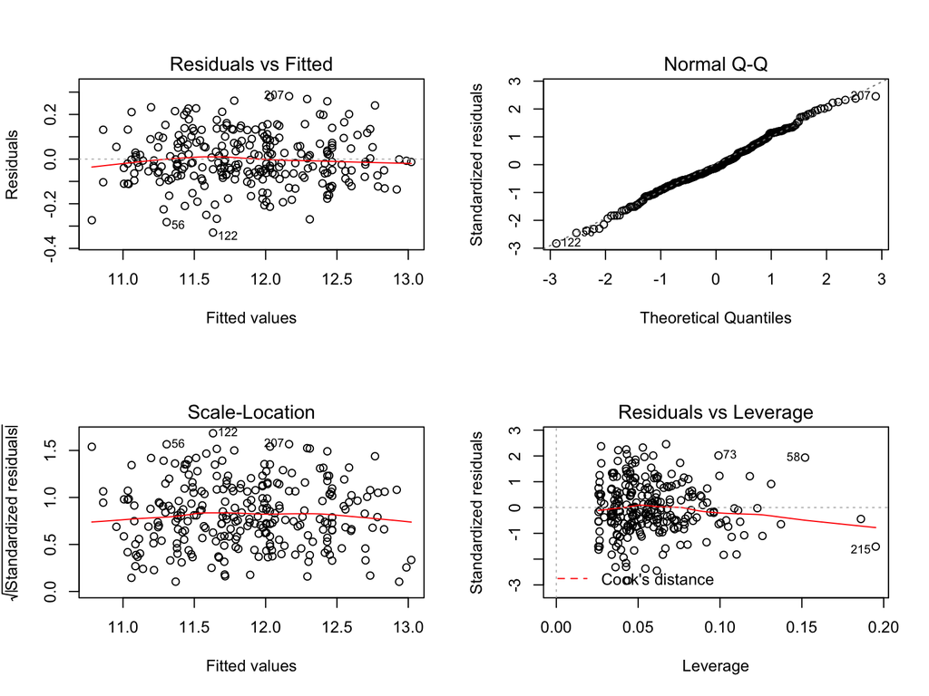

```r
par(mfrow = c(2, 2))
plot(final_law_model)
```

As seen, the Residuals vs. Fitted graph has a nearly straight line at 0, meaning that the assumption of homoscedascity is valid. This is confirmed by the straight line in the Scale-Location graph as well. The Normal Q-Q Plot shows a straight line that does not have any outliers. Finally, the Residuals vs. Leverage graph shows us that there are no influential cases, as all points are well within Cook’s distance, and the dashed line for Cook’s distance cannot even be seen in the graph. Therefore, we can proceed with this final recommended model.